# ML2 - Regression

```python
evaluate = model_eval('XGB Random', pred_xgb_random,evaluate)
evaluate= evaluate.sort_values("MAPE", ignore_index= True)
evaluate
```

|  | model_name | MAE | MSE | RMSE | MAPE |
| --- | --- | --- | --- | --- | --- |
| 0 | RF Base | 1.614465 | 5.793871 | 2.407046 | 0.020136 |
| 1 | RF Grid | 1.664201 | 6.220281 | 2.494049 | 0.020766 |
| 2 | RF Random | 1.669632 | 6.242313 | 2.498462 | 0.020833 |
| 3 | Multiple Regression | 1.682439 | 5.749562 | 2.397824 | 0.020955 |
| 4 | XGB Base | 1.686992 | 6.547152 | 2.558740 | 0.021020 |
| 5 | XGB Random | 1.836264 | 8.441012 | 2.905342 | 0.022855 |

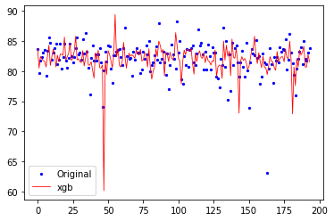

```python
viz_eval(pred_xgb_random, 'xgb')
```

```python
xgb_cv_random.best_params_
```

```
{'xgbregressor__subsample': 0.7,
 'xgbregressor__objective': 'reg:squarederror',
 'xgbregressor__n_estimators': 1000,
 'xgbregressor__min_child_weight': 5.0,
 'xgbregressor__max_depth': 15,
 'xgbregressor__learning_rate': 0.1,
 'xgbregressor__gamma': 0}
```

RandomizedSearchCV was used to narrow down the search space for GridSearch. The best parameters on the train data was achieved with

```
'xgbregressor__subsample': 0.7,
 'xgbregressor__objective': 'reg:squarederror',
 'xgbregressor__n_estimators': 1000,
 'xgbregressor__min_child_weight': 5.0,
 'xgbregressor__max_depth': 15,
 'xgbregressor__learning_rate': 0.1,
 'xgbregressor__gamma': 0
```

Therefore, we define the search grid as follows:

```python
param_grid = {
    'xgbregressor__subsample': [0.5,0.7,0.9],
    'xgbregressor__objective': ['reg:squarederror'],
    'xgbregressor__n_estimators': [800,1000,1500],
    'xgbregressor__min_child_weight': [4,5,6],
    'xgbregressor__max_depth': [10,15,20],
    'xgbregressor__learning_rate': [0.01,0.1],
    'xgbregressor__gamma': [0],
    'xgbregressor__eval_metric': ['rmse'],
    'xgbregressor__colsample_bytree': [0.5]
#     'xgbregressor__colsample_bytree': [0.2,0.3,0.4]
}
```

```python
%%time

# Instantiation
xgb_base = xgb.XGBRegressor(objective ='reg:squarederror', seed = 42, n_jobs  = -1)

# Define pipeline
xgb_model_pipe = model_pipeline(xgb_base, numTransform=False)

# Define Grid
xgb_cv_grid = GridSearchCV(xgb_model_pipe, param_grid, cv=5, n_jobs=-1
                           , scoring = 'neg_mean_absolute_percentage_error'
                          )
# Fit model
xgb_cv_grid.fit(X_train,y_train)
```

```
CPU times: user 16.2 s, sys: 210 ms, total: 16.4 s
Wall time: 12min 29s
```

```
GridSearchCV(cv=5,
             estimator=Pipeline(steps=[('columntransformer',
                                        ColumnTransformer(transformers=[('categorical',
                                                                         Pipeline(steps=[('encoder',
                                                                                          OneHotEncoder(handle_unknown='ignore'))]),
                                                                         ['country_of_origin',
                                                                          'variety',
                                                                          'processing_method',
                                                                          'harvest_year',
                                                                          'color'])])),
                                       ('xgbregressor',
                                        XGBRegressor(base_score=None,
                                                     booster=None,
                                                     callbacks=None,
                                                     colsample_bylevel...
                         'xgbregressor__eval_metric': ['rmse'],
                         'xgbregressor__gamma': [0],
                         'xgbregressor__learning_rate': [0.01, 0.1],
                         'xgbregressor__max_depth': [10, 15, 20],
                         'xgbregressor__min_child_weight': [4, 5, 6],
                         'xgbregressor__n_estimators': [800, 1000, 1500],
                         'xgbregressor__objective': ['reg:squarederror'],
                         'xgbregressor__subsample': [0.5, 0.7, 0.9]},
             scoring='neg_mean_absolute_percentage_error')
```

```python
# Save Model
joblib.dump(xgb_cv_grid.best_estimator_, 'xgb_cv_grid.pkl', compress = 1)
```

```
['xgb_cv_grid.pkl']
```

```python
# predict
pred_xgb_tuned_pipline = xgb_cv_grid.predict(X_test)
```

```python
# Evaluate model
evaluate = model_eval('XGB Grid', pred_xgb_tuned_pipline,evaluate)
evaluate= evaluate.sort_values("MAPE", ignore_index= True)
evaluate
```

|  | model_name | MAE | MSE | RMSE | MAPE |
| --- | --- | --- | --- | --- | --- |
| 0 | RF Base | 1.614465 | 5.793871 | 2.407046 | 0.020136 |
| 1 | RF Grid | 1.664201 | 6.220281 | 2.494049 | 0.020766 |
| 2 | RF Random | 1.669632 | 6.242313 | 2.498462 | 0.020833 |
| 3 | Multiple Regression | 1.682439 | 5.749562 | 2.397824 | 0.020955 |
| 4 | XGB Grid | 1.682604 | 5.900777 | 2.429152 | 0.020959 |
| 5 | XGB Base | 1.686992 | 6.547152 | 2.558740 | 0.021020 |
| 6 | XGB Random | 1.836264 | 8.441012 | 2.905342 | 0.022855 |

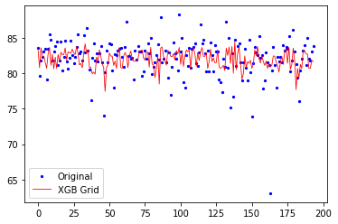

```python
viz_eval(pred_xgb_tuned_pipline, 'XGB Grid')
```

```python
# Get best parameters from grid search
xgb_cv_grid.best_params_
```

```
{'xgbregressor__colsample_bytree': 0.5,
 'xgbregressor__eval_metric': 'rmse',
 'xgbregressor__gamma': 0,
 'xgbregressor__learning_rate': 0.01,
 'xgbregressor__max_depth': 15,
 'xgbregressor__min_child_weight': 6,
 'xgbregressor__n_estimators': 800,
 'xgbregressor__objective': 'reg:squarederror',
 'xgbregressor__subsample': 0.5}
```

The best result was achieved in the grid search with the parameters:

```
'xgbregressor__colsample_bytree': 0.5,
 'xgbregressor__eval_metric': 'rmse',
 'xgbregressor__gamma': 0,
 'xgbregressor__learning_rate': 0.01,
 'xgbregressor__max_depth': 15,
 'xgbregressor__min_child_weight': 6,
 'xgbregressor__n_estimators': 800,
 'xgbregressor__objective': 'reg:squarederror',
 'xgbregressor__subsample': 0.5
```

The tuning of the model has increased the fit of the base model. The tuned model slightly underperforms the Simple Regression model.

### Deep Learning

As the last state-of-the-art approach we are using a Multi Layer Perception (MLP). MLP utilizes a supervised learning technique called backpropagation for training. Its multiple layers and non-linear activation distinguish MLP from a linear perceptron. It can distinguish data that is not linearly separable.MLP utilizes a supervised learning technique called backpropagation for training. Its multiple layers and non-linear activation distinguish MLP from a linear perceptron. It can distinguish data that is not linearly separable (‘Multilayer Perceptron’ 2023).

‘Multilayer Perceptron’. In Wikipedia, 6 February 2023. https://en.wikipedia.org/w/index.php?title=Multilayer_perceptron&oldid=1137841114 Page Version ID: 1137841114.

```python
# Keras setup
# !pip install -U tensorflow==2.11.0
# !pip install tensorflow-cpu
# !pip install scikeras
import tensorflow as tf
from tensorflow.keras.models import Sequential
from tensorflow.keras.layers import Dense
from tensorflow.keras.layers import Dropout
from scikeras.wrappers import KerasRegressor
from tensorflow.keras.layers import Dropout
from tensorflow.keras.constraints import MaxNorm
from tensorflow.keras.optimizers import Adam
```

For setting up a neural network the question of how many hidden layers and how many neurons should be used. Literature suggests mostly an arbitrary choice but some rule of thumbs exist.

Based on Heaton (2017) these rule of thumbs exist:

**Number of Hidden Layers:**

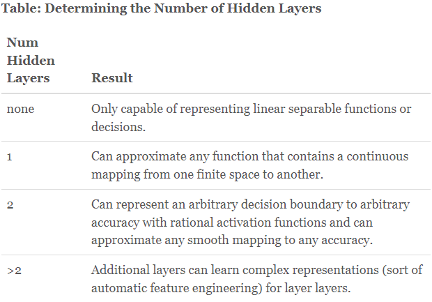

Based on this we decide to use 3 hidden layers.

**Number of Neurons:**

Generally, a large enough single layer network can approximate any other neural network, at least in theory.Generally, a large enough single layer network can approximate any other neural network, at least in theory.

This is way we have choosen a 24-12-8 layout of the hidden layers.

A common optimization algorithm is Adam. It is described as "computationally efficient, has little memory requirement, invariant to diagonal rescaling of gradients, and is well suited for problems that are large in terms of data/parameters"(Kingma et al., 2014). Therefore, we chose it for our model.

Data scaling is a recommended pre-processing step when working with deep learning neural networks (Brownlee 2019). Therfore, we will use the StandardScalar in the Pipeline.

Source:  
Heaton, Jeff. ‘The Number of Hidden Layers’. Heaton Research, 1 June 2017. https://www.heatonresearch.com/2017/06/01/hidden-layers.html.

Kingma, Diederik P., and Jimmy Ba. ‘Adam: A Method for Stochastic Optimization’. arXiv, 29 January 2017. https://doi.org/10.48550/arXiv.1412.6980 arXiv:1412.6980 [cs].

Brownlee, Jason. 2019. ‘How to Use Data Scaling Improve Deep Learning Model Stability and Performance’. MachineLearningMastery.Com (blog). 3 February 2019. https://machinelearningmastery.com/how-to-improve-neural-network-stability-and-modeling-performance-with-data-scaling/.

#### Base Model

```python
%%time
# Build simple model
def create_model():
    model = Sequential()
    # Input layer and first hidden layer
    model.add(Dense(24, input_dim=32,activation='relu'))
    # second hidden layer
    model.add(Dense(12, activation='relu'))
    # third hidden layer
    model.add(Dense(8,activation='relu'))
    # output layer
    model.add(Dense(1,activation='linear'))
    # compile model
    model.compile(loss="mean_squared_error", optimizer="adam")
    return model

# fix random seed for reproducibility
seed = 42
tf.random.set_seed(seed)

# set up model
mlp_estimator = KerasRegressor(model=create_model, epochs=100, batch_size=10, verbose=0,random_state = 42)
mlp_pipeline = model_pipeline(mlp_estimator)
param_grid = {}
mlp_base = GridSearchCV(estimator=mlp_pipeline, param_grid=param_grid, scoring='neg_mean_squared_error', n_jobs=-1, cv=3)

# fit model
mlp_model_base = mlp_base.fit(X_train, y_train)
```

```
CPU times: user 26.1 s, sys: 2.07 s, total: 28.2 s
Wall time: 44.7 s
```

```python
# Predict
pred_mlp_base = mlp_base.predict(X_test)

# Evaluate
evaluate = model_eval('MLP', pred_mlp_base,evaluate)
evaluate= evaluate.sort_values("MAPE", ignore_index= True)
evaluate
```

|  | model_name | MAE | MSE | RMSE | MAPE |
| --- | --- | --- | --- | --- | --- |
| 0 | RF Base | 1.614465 | 5.793871 | 2.407046 | 0.020136 |
| 1 | RF Grid | 1.664201 | 6.220281 | 2.494049 | 0.020766 |
| 2 | RF Random | 1.669632 | 6.242313 | 2.498462 | 0.020833 |
| 3 | Multiple Regression | 1.682439 | 5.749562 | 2.397824 | 0.020955 |
| 4 | XGB Grid | 1.682604 | 5.900777 | 2.429152 | 0.020959 |
| 5 | XGB Base | 1.686992 | 6.547152 | 2.558740 | 0.021020 |
| 6 | XGB Random | 1.836264 | 8.441012 | 2.905342 | 0.022855 |
| 7 | MLP | 2.067831 | 7.938232 | 2.817487 | 0.025561 |

#### Tuned Model

```python
%%time

# define neural network
def create_model(optimizer='adam', activation='relu', init_mode='uniform'):
    model = Sequential()
    model.add(Dense(24, input_dim=32, activation=activation, kernel_initializer=init_mode))
    model.add(Dense(12, activation=activation, kernel_initializer=init_mode))
    model.add(Dense(8, activation=activation, kernel_initializer=init_mode))
    model.add(Dense(1, activation='linear'))
    model.compile(loss="mean_squared_error", optimizer=optimizer)
    return model

# fix random seed for reproducibility
seed = 7
tf.random.set_seed(seed)

# create model
model = KerasRegressor(model=create_model, epochs=100, batch_size=10, verbose=0, random_state = 42)
pipe = model_pipeline(model)

# define grid
param_grid = {
#             'kerasregressor__model__optimizer__optimizer': ['adam', 'rmsprop'],
              'kerasregressor__epochs': [900,1000,1100],
              'kerasregressor__batch_size': [5,10],
#               'kerasregressor__model__weight_constraint' : [1.0,3.0,5.0],
#               'kerasregressor__model__dropout_rate' : [0.0,0.3,0.5,0.7,0.9]
#               'kerasregressor__model__activation': ['relu', 'tanh'],
#               'kerasregressor__model__init_mode': ['uniform', 'lecun_uniform']
             }

# grid search
mlp_grid = GridSearchCV(estimator=pipe, param_grid=param_grid, scoring='neg_mean_squared_error', n_jobs=-1, cv=3)

# fit model
mlp_grid_result = mlp_grid.fit(X_train, y_train)
```

```
CPU times: user 4min 25s, sys: 21.4 s, total: 4min 46s
Wall time: 20min 12s
```

```python
# Predict on test set
pred_mlp_grid = mlp_grid_result.predict(X_test)
```

```python
# Evaluate model
evaluate = model_eval('MLP Grid', pred_mlp_grid,evaluate)
evaluate= evaluate.sort_values("MAPE", ignore_index= True)
evaluate
```

|  | model_name | MAE | MSE | RMSE | MAPE |
| --- | --- | --- | --- | --- | --- |
| 0 | RF Base | 1.614465 | 5.793871 | 2.407046 | 0.020136 |
| 1 | RF Grid | 1.664201 | 6.220281 | 2.494049 | 0.020766 |
| 2 | RF Random | 1.669632 | 6.242313 | 2.498462 | 0.020833 |
| 3 | Multiple Regression | 1.682439 | 5.749562 | 2.397824 | 0.020955 |
| 4 | XGB Grid | 1.682604 | 5.900777 | 2.429152 | 0.020959 |
| 5 | XGB Base | 1.686992 | 6.547152 | 2.558740 | 0.021020 |
| 6 | XGB Random | 1.836264 | 8.441012 | 2.905342 | 0.022855 |
| 7 | MLP | 2.067831 | 7.938232 | 2.817487 | 0.025561 |
| 8 | MLP Grid | 2.309299 | 8.448761 | 2.906675 | 0.028288 |

```python
mlp_grid_result.best_params_
```

```
{'kerasregressor__batch_size': 10, 'kerasregressor__epochs': 1000}
```

The best result was achieved in the grid search with the parameters:  
`'kerasregressor__batch_size': 10, 'kerasregressor__epochs': 1000`

The tuning of the model has decreased the fit of the base model which indicates overfitting of the base model. The tuned model underperforms all other models..

## Summary

As we can see from the table below state-of-the-art models do not always deliver better results than well established simple methods.

We can see, that Random Forest performed best for our use case and MLP worst. Considering runtime, MLP is the most runtime consuming method whereas Simple Regression is the least.

We also saw that it is important to avoid data leakage and take appropriate measures to prevent it. Also we saw that Random Forest's base model delivered a better result on the testing set but those result did not seem stable and reproducable in hyperparameter tuning where avoiding overfitting was very important.

In gerneral, we can reasonably good predict the quality of coffee by only knowing its specifics available when purchasing.

```python
evaluate
```

[output not shown]

```python
# Get numerical feature importances
importances = list(rf_cv_grid.best_estimator_['randomforestregressor'].feature_importances_)
# List of tuples with variable and importance
feature_importances = [(feature, round(importance, 2)) for feature, importance in zip(X_train, importances)]
# Sort the feature importances by most important first
feature_importances = sorted(feature_importances, key = lambda x: x[1], reverse = True)
# Print out the feature and importances
[print('Variable: {:20} Importance: {}'.format(*pair)) for pair in feature_importances];
```

```
Variable: processing_method    Importance: 0.28
Variable: variety              Importance: 0.27
Variable: harvest_year         Importance: 0.05
Variable: color                Importance: 0.04
Variable: number_of_bags       Importance: 0.03
Variable: category_one_defects Importance: 0.02
Variable: country_of_origin    Importance: 0.01
Variable: category_two_defects Importance: 0.01
Variable: moisture             Importance: 0.01
Variable: altitude_mean_meters Importance: 0.01
```

Also we can visulize one one the trees of the forest to get a feeling how the determination is done.

```python
# Import tools needed for visualization
from sklearn.tree import export_graphviz
import pydot

feature_list = rf_cv_grid.best_estimator_[:-1].get_feature_names_out()
# Pull out one tree from the forest
tree = rf_cv_grid.best_estimator_['randomforestregressor'].estimators_[5]
# rf_cv_grid.best_estimator_['randomforestregressor'].fe
# Export the image to a dot file
export_graphviz(tree, out_file = 'tree.dot', feature_names = feature_list, rounded = True, precision = 1)
# Use dot file to create a graph
(graph, ) = pydot.graph_from_dot_file('tree.dot')
# Write graph to a png file
graph.write_png('tree.png')
```

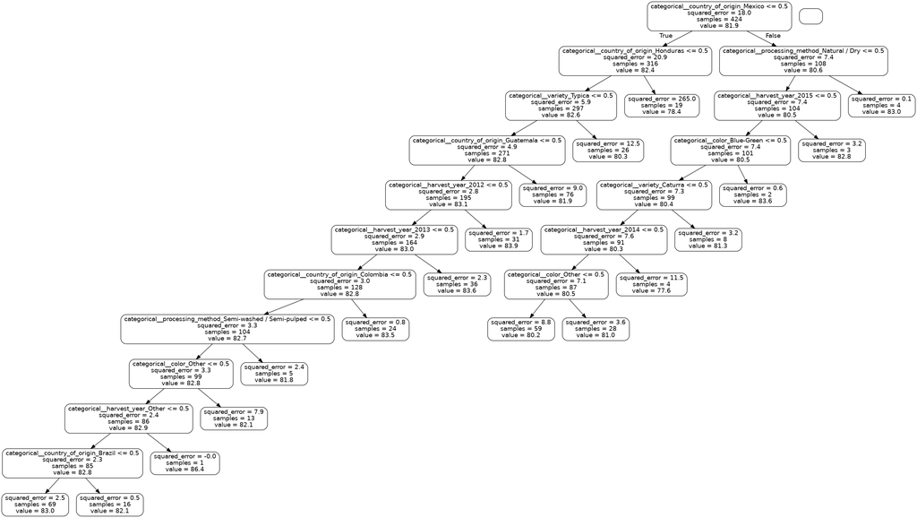

As we can see as an example that Mexican natural/ dry processed coffee seems to yield good results.